# Lord’s Paradox

## The Question

- A university has two dormitories with two different cafeteria menus. We want to know:
  - How do students' weights change over the course of their first year at university?

## What is the effect of the different menus on student weight change?

Students in the two dormitories are weighed at the beginning and end of the school year:

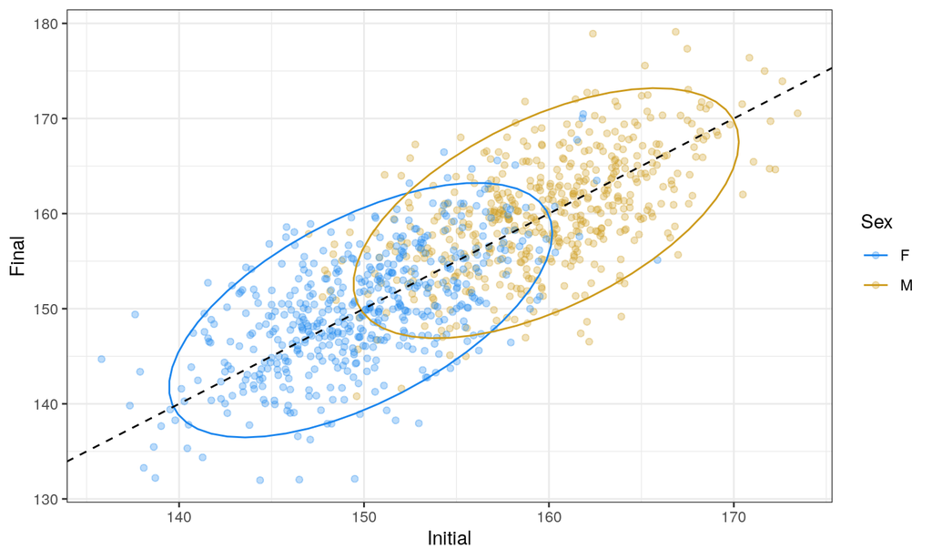

Two statisticians analyze these data.

## Anova

```r
l_a_anov = aov(Weight ~ Timepoint, filter(l_df_long, Sex == 'F'))
l_b_anov = aov(Weight ~ Timepoint, filter(l_df_long, Sex == 'M'))
Anova(l_a_anov)
```

```
## Anova Table (Type II tests)
##
## Response: Weight
##           Sum Sq  Df F value Pr(>F)
## Timepoint      0   1       0  0.995
## Residuals  31589 998
```

```r
Anova(l_b_anov)
```

```
## Anova Table (Type II tests)
##
## Response: Weight
##            Sum Sq  Df F value Pr(>F)
## Timepoint    14.5   1  0.4677 0.4942
## Residuals 30881.4 998
```

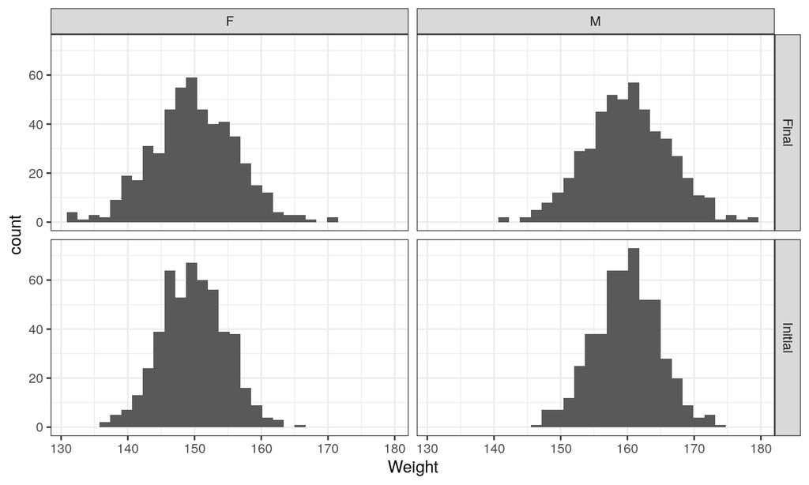

But we can do an equivalent thing with a linear model:

```r
l_mod1 = lm(Gain ~ Sex, data = l_df)
summary(l_mod1)
```

```
##
## Call:
## lm(formula = Gain ~ Sex, data = l_df)
##
## Residuals:
##      Min       1Q   Median       3Q      Max
## -17.3924  -3.4087  -0.0579   3.4634  16.2929
##
## Coefficients:
##             Estimate Std. Error t value Pr(>|t|)
## (Intercept) 0.002246   0.232175   0.010    0.992
## SexM        0.238358   0.328345   0.726    0.468
##
## Residual standard error: 5.192 on 998 degrees of freedom
## Multiple R-squared:  0.0005278,  Adjusted R-squared:  -0.0004737
## F-statistic: 0.527 on 1 and 998 DF,  p-value: 0.468
```

```r
l_em_df = data.frame(emmeans(l_mod1, 'Sex'))
```

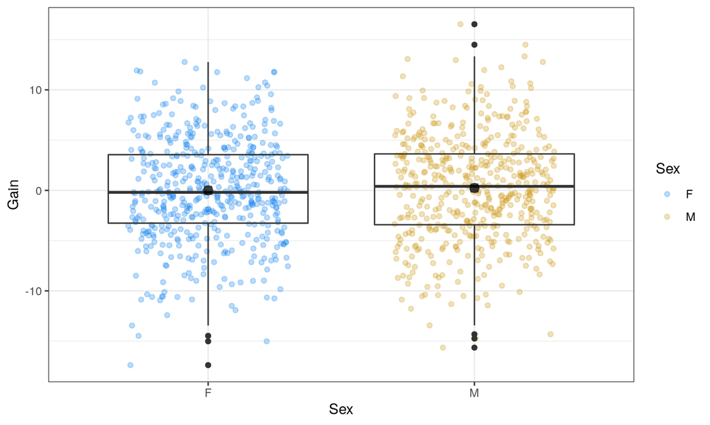

## ANCOVA

- The second statistician decides to control for the initial weight of the students
  - The slopes of the regression lines between initial and final weights are similar in the two dorms, which allows them to compare the intercepts with an ANCOVA:

```r
l_ancov = aov(Final ~ Sex + Initial, data = l_df)
Anova(l_ancov)
```

```
## Anova Table (Type II tests)
##
## Response: Final
##            Sum Sq  Df F value    Pr(>F)
## Sex         851.9   1  33.274 1.067e-08 ***
## Initial   13481.6   1 526.599 < 2.2e-16 ***
## Residuals 25524.4 997
## ---
## Signif. codes:  0 '***' 0.001 '**' 0.01 '*' 0.05 '.' 0.1 ' ' 1
```

And indeed, it is clear from the graph that the two regression lines will have very different intercepts:

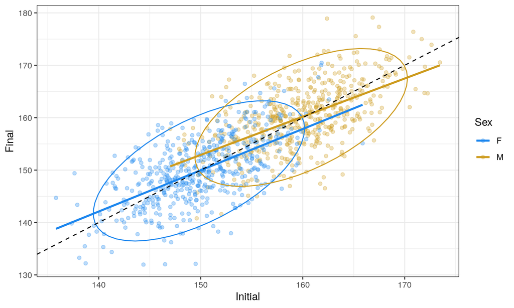

In other words: Students in Sex B are gaining more weight than students in Sex B because *for any given initial weight*, the average final weight in Sex B is higher than Sex A.

So, what is going on here?

## A Digression: Mediation

Let's construct a different data set. In this data set students in Sex B will gain more weight than students in Sex B, and this gain will be *mediated* by initial weight. I.e., the more you weight initially, the more you gain.

```r
# Start with 1000 students
m_a_0 = rnorm(500, 150, 5)
m_b_0 = rnorm(500, 160, 5)

# Final weight (and therefore weight gain) solely a function of initial weight
m_a_f = (1+delt)*m_a_0 + rnorm(500, 0, 1)
m_b_f = (1+delt)*m_b_0 + rnorm(500, 0, 1)

m_df = data.frame(Sex = rep(c('F','M'), each = 500),
                Initial = c(m_a_0, m_b_0),
                Final = c(m_a_f, m_b_f),
                Gain = c(m_a_f - m_a_0, m_b_f - m_b_0))
head(m_df)
```

```
##   Sex  Initial    Final     Gain
## 1   F 156.2228 186.8056 30.58282
## 2   F 147.8403 177.5124 29.67215
## 3   F 150.0343 179.1848 29.15046
## 4   F 150.6228 179.4170 28.79424
## 5   F 147.9519 175.9447 27.99282
## 6   F 152.8171 183.9047 31.08763
```

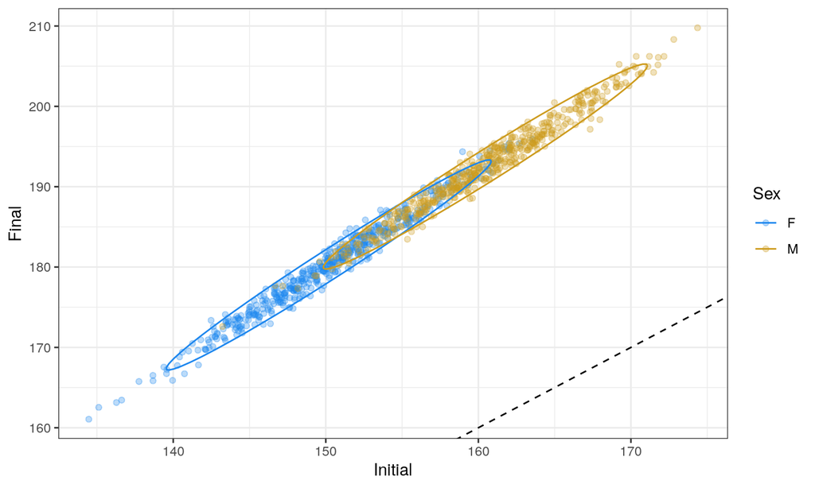

```r
m_df_long = (m_df
           %>% select(-Gain)
           %>% gather(Timepoint, Weight, Initial, Final))

ggplot(m_df, aes(Initial, Final)) +
    geom_point(aes(colour = Sex), alpha = 0.3) +
    stat_ellipse(aes(colour = Sex)) +
    # geom_smooth(aes(colour = Sex), method = 'lm',
    #           se = FALSE) +
    geom_abline(intercept = 0, slope = 1, linetype = 2) +
    scale_colour_manual(values = cols)
```

In this case, both groups of students are gaining weight, but that gain is only related to the initial weight. There is no direct effect of Sex.

### ANOVA

Let's do what Lord's first hypothetical statistician did, and run an ANOVA:

```r
m_a_anov = aov(Weight ~ Timepoint, filter(m_df_long, Sex == 'F'))
m_b_anov = aov(Weight ~ Timepoint, filter(m_df_long, Sex == 'M'))
Anova(m_a_anov)
```

```
## Anova Table (Type II tests)
##
## Response: Weight
##           Sum Sq  Df F value    Pr(>F)
## Timepoint 226213   1  7207.9 < 2.2e-16 ***
## Residuals  31321 998
## ---
## Signif. codes:  0 '***' 0.001 '**' 0.01 '*' 0.05 '.' 0.1 ' ' 1
```

```r
Anova(m_b_anov)
```

```
## Anova Table (Type II tests)
##
## Response: Weight
##           Sum Sq  Df F value    Pr(>F)
## Timepoint 257074   1  8649.9 < 2.2e-16 ***
## Residuals  29661 998
## ---
## Signif. codes:  0 '***' 0.001 '**' 0.01 '*' 0.05 '.' 0.1 ' ' 1
```

Looking at the distributions, it's clear their location has moved:

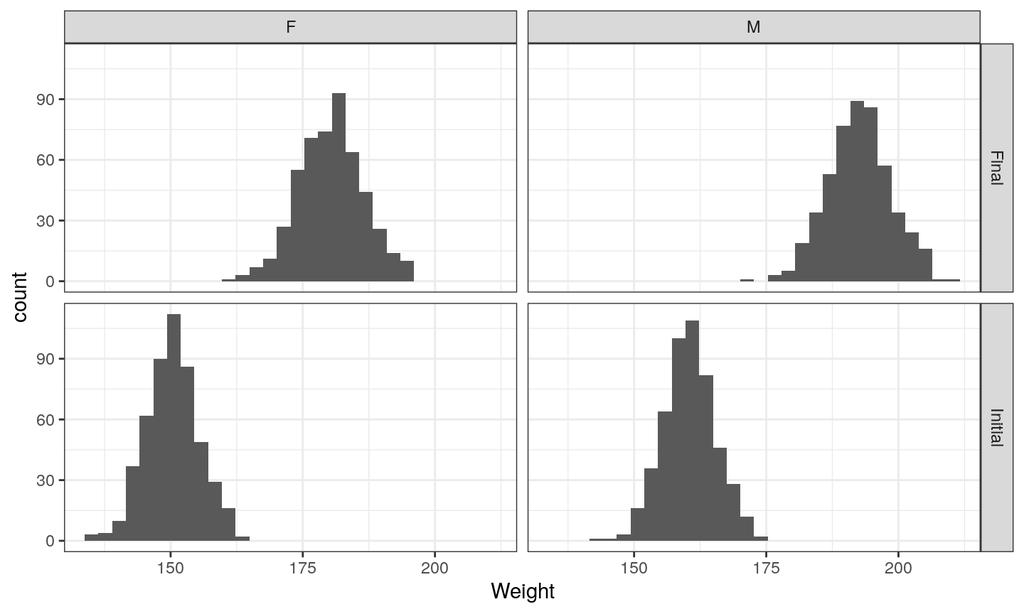

And here is the equivalent linear model:

```r
m_mod1 = lm(Gain ~ Sex, data = m_df)
summary(m_mod1)
```

```
##
## Call:
## lm(formula = Gain ~ Sex, data = m_df)
##
## Residuals:
##     Min      1Q  Median      3Q     Max
## -4.1488 -0.9631 -0.0243  0.9729  5.3152
##
## Coefficients:
##             Estimate Std. Error t value Pr(>|t|)
## (Intercept) 30.08074    0.06379  471.55   <2e-16 ***
## SexM         1.98633    0.09022   22.02   <2e-16 ***
## ---
## Signif. codes:  0 '***' 0.001 '**' 0.01 '*' 0.05 '.' 0.1 ' ' 1
##
## Residual standard error: 1.426 on 998 degrees of freedom
## Multiple R-squared:  0.3269, Adjusted R-squared:  0.3263
## F-statistic: 484.8 on 1 and 998 DF,  p-value: < 2.2e-16
```

```r
m_em_df = data.frame(emmeans(m_mod1, 'Sex'))
```

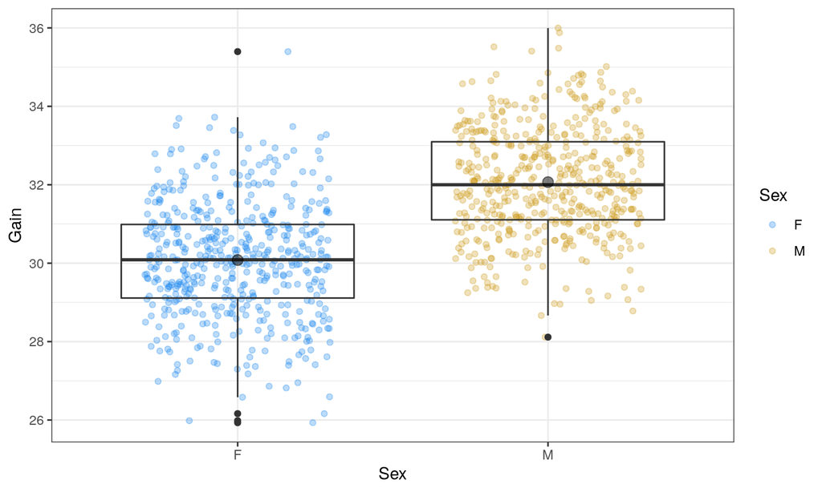

When we don't control for initial weight, we see a clear effect of Sex.

### ANCOVA

Now let's follow Lord's second statistician's method. Again. the slopes in the two groups are similar, so we are justified in comparing their intercepts.

```r
m_ancov = aov(Gain ~ Sex + Initial, data = m_df)
Anova(m_ancov)
```

```
## Anova Table (Type II tests)
##
## Response: Gain
##            Sum Sq  Df  F value Pr(>F)
## Sex          0.34   1   0.3165 0.5738
## Initial    971.30   1 914.1465 <2e-16 ***
## Residuals 1059.33 997
## ---
## Signif. codes:  0 '***' 0.001 '**' 0.01 '*' 0.05 '.' 0.1 ' ' 1
```

Effect of Sex is no longer significant!

Linear model framework:

```r
m_mod2 = lm(Gain ~ Sex + Initial, data = m_df)
summary(m_mod2)
```

```
##
## Call:
## lm(formula = Gain ~ Sex + Initial, data = m_df)
##
## Residuals:
##     Min      1Q  Median      3Q     Max
## -3.6004 -0.6670 -0.0240  0.7074  3.5838
##
## Coefficients:
##              Estimate Std. Error t value Pr(>|t|)
## (Intercept)  0.218290   0.988758   0.221    0.825
## SexM        -0.052771   0.093800  -0.563    0.574
## Initial      0.198751   0.006574  30.235   <2e-16 ***
## ---
## Signif. codes:  0 '***' 0.001 '**' 0.01 '*' 0.05 '.' 0.1 ' ' 1
##
## Residual standard error: 1.031 on 997 degrees of freedom
## Multiple R-squared:  0.6489, Adjusted R-squared:  0.6482
## F-statistic: 921.2 on 2 and 997 DF,  p-value: < 2.2e-16
```

The intercept and effect of Sex have both disappeared. Indeed, the intercepts of the two regression lines are the same.

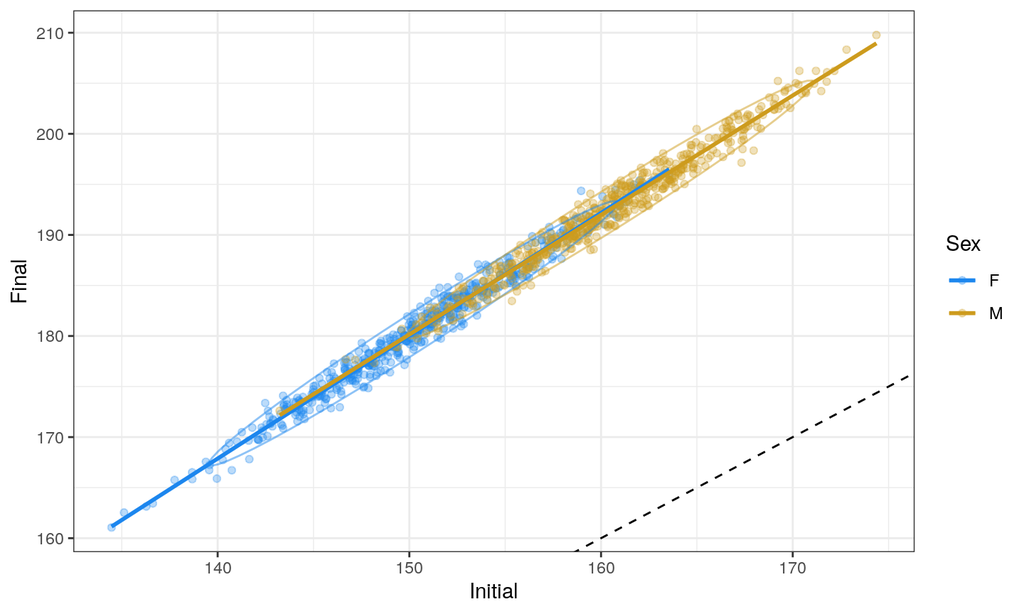

So, what happened here? Who is correct?

### Everyone is right; context is everything

[figure not shown]

Statistician 1 is testing the **total effect** of sex on weight gain:

\[ TE = E(G|S = 1) - E(G|S = 0) \]

or

\[ TE = (b + ac) - a \]

\[ TE = b - a(1-c) \]

Statistician 2 is testing the **direct effect** of sex on weight gain:

\[ DE = \sum_w[E(G|S = 1, W_I = w) - E(G|S = 0, W_I = w)]P(W_I = w|S = 0) \]

or

\[ DE = b \]

In this toy example we know that \(b = 0\), and it seems clear that Sex is a red herring. But that is less obvious in real life examples:

- Poverty, toxins, cancer
  - what can you measure?
  - what info can clinicians access?
  - what policies are you trying to inform?

The fact that the effect of X on Y is *mediated* by M doesn't mean that the effect is not real, or not important. Nor does it mean that M doesn't matter. It's all real.

## Connect Mediation back to Lord

Lord's dataset can be thought of in the same way:

[figure not shown]

In this case, \(b\) is not zero, but I chose values for \(b\), \(a\), and \(c\) such that \(b = a(1 - c)\) and therefore \(TE = 0\).

You can see this more clearly if I plot Gain vs. \(W_I\), instead of \(W_F\) vs. \(W_I\) as Lord did:

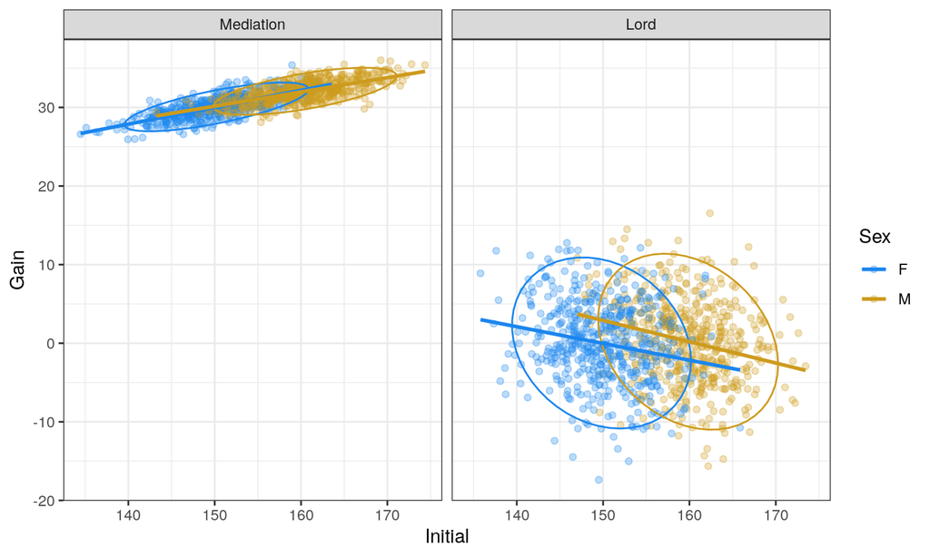

Which is what leads us to our different conclusions.

\[ G \sim \beta_{10} + \beta_{11} * S \]

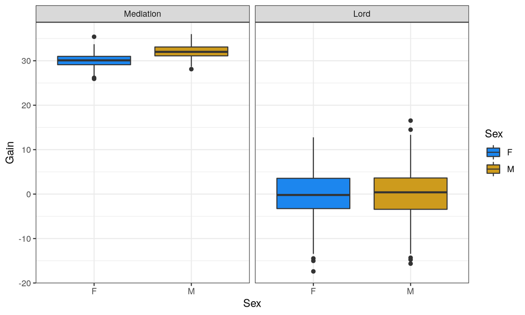

The first statistician was testing the *total effect* of sex

There is no need for the mediating variable to be the baseline value of the response variable. E.g.

- Sex
- Body fat % (not actually linear but never mind)
- Cardiovascular disease

## References

Most of this is borrowed from [Judea Pearl's explanation](https://ftp.cs.ucla.edu/pub/stat_ser/r436.pdf) of the problem.